# Pandas Tutorial

Introduction to pandas

Pandas is an open-source, BSD-licensed Python library providing high-performance, easy-to-use data structures and data analysis tools for the Python programming language. Python with Pandas is used in a wide range of fields including academic and commercial domains including finance, economics, Statistics, analytics, etc. In this tutorial, we will learn the various features of Python Pandas and how to use them in practice.

Before Pandas, Python was capable for data preparation, but it only provided limited support for data analysis. So, Pandas came into the picture and enhanced the capabilities of data analysis. It can perform five significant steps required for processing and analysis of data irrespective of the origin of the data, i.e., load, manipulate, prepare, model, and analyze

###### Key Features of Pandas

1.It has a fast and efficient DataFrame object with the default and customized indexing.</br> 2.Used for reshaping and pivoting of the data sets.</br> 3.Group by data for aggregations and transformations.</br> 4.It is used for data alignment and integration of the missing data.</br> 5.Provide the functionality of Time Series.</br> 6.Process a variety of data sets in different formats like matrix data, tabular heterogeneous, time series.</br> 7.Handle multiple operations of the data sets such as subsetting, slicing, filtering, groupBy, re-ordering, and re-shaping.</br> 8.It integrates with the other libraries such as SciPy, and scikit-learn.</br> 9.Provides fast performance, and If you want to speed it, even more, you can use the Cython.</br>

###### Benefits of Pandas

1.The benefits of pandas over using other language are as follows:</br> 2.Data Representation: It represents the data in a form that is suited for data analysis through its DataFrame and Series.</br> 3.Clear code: The clear API of the Pandas allows you to focus on the core part of the code. So, it provides clear and concise code for the user.

#### Topics Covered

1 Creating, Reading and Writing</br> 2 Indexing, Selecting & Assigning</br> 3 Summary Functions and Maps</br> 4 Grouping and Sorting</br> 5 Data Types and Missing Values</br> 6 Renaming and Combining</br> 7.Comparison with SQL</br>

#### 1.Creating, Reading and Writing

##### 1.1 Import Pandas in Python

The very first and the most important operation is to import the Python Pandas library properly. While importing Pandas library, we abbreviate it as pd.

```python
#import pandas as pd
```

##### 1.2 Creating data

```python
There are two core objects in pandas: the DataFrame and the Series.
```

###### 1.2.1) DataFrame

Pandas DataFrame is two-dimensional size-mutable, potentially heterogeneous tabular data structure with labeled axes (rows and columns). A Data frame is a two-dimensional data structure, i.e., data is aligned in a tabular fashion in rows and columns. Pandas DataFrame consists of three principal components, the data, rows, and columns.

[figure not shown]

###### a)Creating a DataFrame from a list:

```python
# Let’s take a list of integers and then create a DataFrame using that Python list.

list1 = [1,2,3,4,5]
```

[output not shown]

###### b)Creating a DataFrame from a list of lists

```python
import pandas as pd

# List of lists
list_of_lists = [['John', 25, 'USA'], ['Alice', 30, 'Canada'], ['Bob', 28, 'Australia']]

# Creating a DataFrame
df = pd.DataFrame(list_of_lists, columns=['Name', 'Age', 'Country'])

# Displaying the DataFrame
print(df)

#Code Explanation
# The code creates a DataFrame from a list of lists using the pandas library in Python.
# First, we import the pandas library using the import pandas as pd statement.
# We define a list of lists called list_of_lists, where each inner list represents a row of data. In this example, the inner lists contain the name, age, and country of a person.
# Next, we create a DataFrame using the pd.DataFrame() function. We pass the list_of_lists as the data parameter and specify the column names as ['Name', 'Age', 'Country'] using the columns parameter.
# Finally, we print the DataFrame df using print(df), which displays the data in a tabular format.
# The resulting DataFrame df has three columns ('Name', 'Age', 'Country') and three rows, where each row represents a person's data. This code demonstrates how to convert a list of lists into a DataFrame, which is a convenient data structure for working with tabular data in Python.
```

```
    Name  Age    Country
0   John   25        USA
1  Alice   30     Canada
2    Bob   28  Australia
```

###### c) Importing Data with Pandas in Python

```python
#import pandas as pd
#Product_Review=pd.read_csv(“Amazon_Products_Review.csv”)
#Overall, this code allows you to load data from a CSV file into a DataFrame,
#enabling you to perform various operations, such as analyzing the data, filtering rows, calculating statistics, or visualizing the information.
```

```python
# For file types other than .csv, the importing conventions are mentioned below:

# pd.read_table(“filename”)
# pd.read_excel(“filename”)
# pd.read_sql(query, connection_object)
# pd.read_json(json_string)
```

###### 1.2.2) Series

Pandas Series is a one-dimensional labeled array capable of holding data of any type (integer, string, float, python objects, etc.). Pandas Series is nothing but a column in an excel sheet.

```python
# import pandas as pd
import pandas as pd

# simple array
data = [1, 2, 3, 4]

ser = pd.Series(data)
print(ser)
```

```
0    1
1    2
2    3
3    4
dtype: int64
```

[figure not shown]

###### a)Creating a Series

In the real world, a Pandas Series will be created by loading the datasets from existing storage, storage can be SQL Database, CSV file, and Excel file. Pandas Series can be created from the lists, dictionary, and from a scalar value etc. Series can be created in different ways, here are some ways by which we create a series:

###### b).Creating a series from array:

```python
# import pandas as pd
import pandas as pd
import numpy as np
#A NumPy array is a collection of elements that have the same data type.
#You can think of it like a container that has several compartments that hold data, as long as the data is of the same data type.
#https://www.sharpsightlabs.com/blog/numpy-array-python/

# simple array
data = np.array(['g','e','e','k','s'])

ser = pd.Series(data)
print(ser)

# this code creates a pandas Series from a NumPy array and then prints the Series,
#showcasing how to convert a NumPy array into a pandas data structure for further analysis and manipulation.
```

```
0    g
1    e
2    e
3    k
4    s
dtype: object
```

###### c).Creating a series from Lists:

```python
#In order to create a series from list, we have to first create a list after that we can create a series from list.

import pandas as pd

# a simple list
list = ['g', 'e', 'e', 'k', 's']

# create series form a list
ser = pd.Series(list)
print(ser)

#this code showcases how to create a pandas Series from a Python list and then prints the Series. It demonstrates the process of converting a list into a pandas data structure for further analysis, manipulation, and utilization of pandas' powerful features
```

```
0    g
1    e
2    e
3    k
4    s
dtype: object
```

###### 1.2.3 Reading data

```python
Here we are taking the loans dataset and trying to understand different operations in pandas
# https://www.kaggle.com/datasets/mirzahasnine/loan-data-set
```

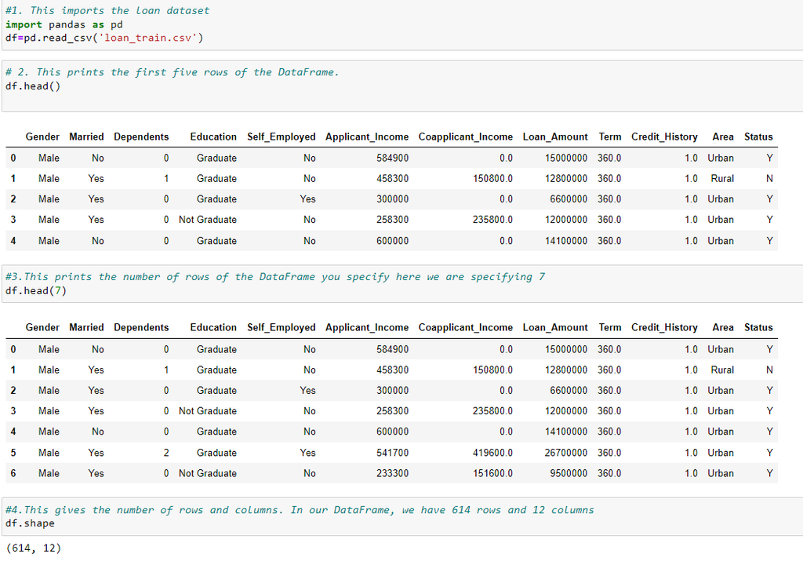

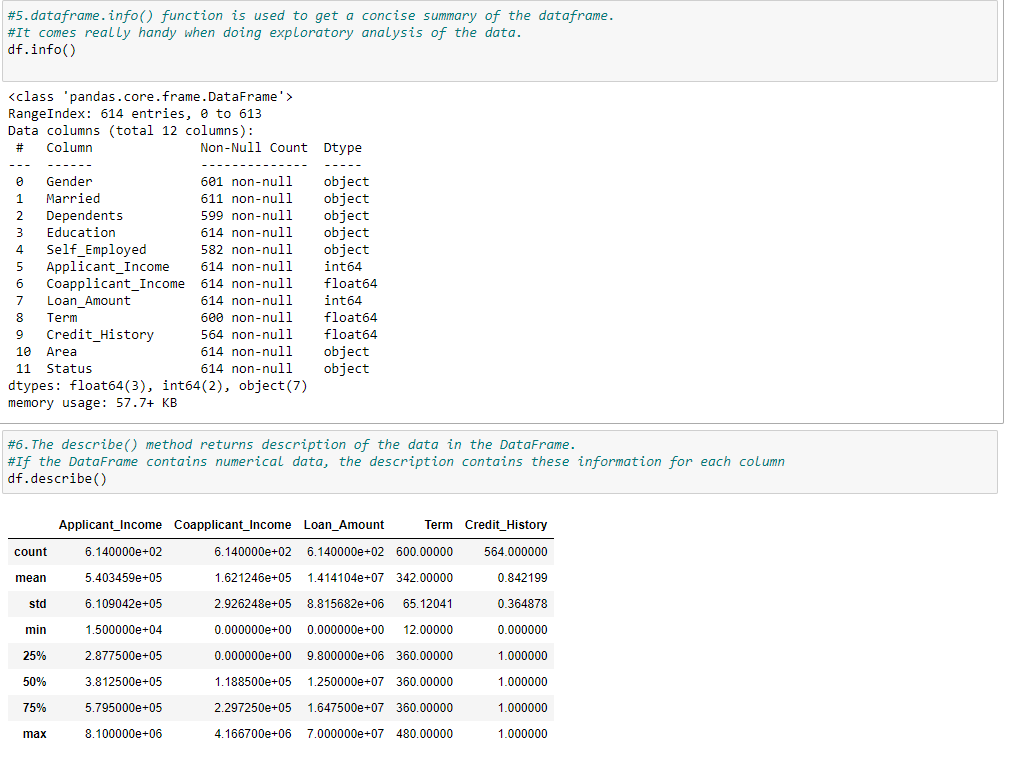

###### 2.Indexing, Selecting & Assigning

###### 2.1 Indexing

Index is like an address, that’s how any data point across the dataframe or series can be accessed. Rows and columns both have indexes, rows indices are called as index and for columns its general column names.

###### 2.2 Selecting

df.loc are for labels/ names </br> df.iloc are for position numbers

e.g. Lets assume Ram, Sonu & Tony are standing at positions 1, 2 & 3 respectively. If you want to call Ram you have two options, either you call him by his name or his position number. So, if you call Ram by his name “Ram”, you will use df.loc and if we will call him by his position number “1” we will use df.iloc.

###### loc

The .loc property of the DataFrame object allows the return of specified rows and/or columns from that DataFrame. It can do so using a label or label(s), or a boolean array of the same size as the axis being filtered.

###### Syntax

dataframevalue.loc[rows,columns]

Note: .loc is not a method, it is a property indexed via square brackets.

Inside the square brackets are specified indices for rows and, optionally, specified indices for columns.

The indices to access can be specified in several ways:

A single label. Note: an integer is treated as a label, not a row or column position. An array of labels. An array of booleans the same size as the index being accessed. Labels using the Python slice notation. Note: slices for .loc will include both endpoints.

###### 1.Select Single Row & Column By Label using loc[]

By using pandas loc[] you can select the rows and columns by name. This also supports selecting multiple rows and columns, records between two rows, between two columns e.t.c

Note :We have loaded the dataframe in df and we are continuining from there

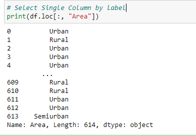